# 2017 Yılı Ülkelerin Mutluluk Sıralamasına İlişkin Veri Analizi Ve Regresyon Modeli İle İncelenmesi

GitHub: Ozgurnrttn

# GİRİŞ

İstatistik, belirli bir amaç için veri toplama, tablo ve grafiklerle özetleme, sonuçları yorumlama, sonuçların güven derecelerini açıklama, örneklerden elde edilen sonuçları kitle için genelleme, özellikler arasındaki ilişkiyi araştırma, çeşitli konularda geleceğe ilişkin tahmin yapma, deney düzenleme ve gözlem ilkelerini kapsayan bir bilimdir. Belirli bir amaç için verilerin toplanması, sınıflandırılması, çözümlenmesi ve sonuçlarının yorumlanması esasına dayanır. Blalock’a göre istatistik olayları tek tek ya da seyrek olarak ortaya çıkan olayları inceleyen bir dal değildir.

*“İstatistik ile yalan söylemek kolaydır; istatistik olmadan gerçeği anlatmak zordur”* (A. Dunkels)

*“Üç çeşit yalan vardır; yalan, kuyruklu yalan, istatistik.”* (Louis Brandeis)

Bu çalışmada 2017 yılı Dünya mutluluk skoru veri seti üzerinde veri analizi ve regresyon analizi üzerine çalışmalar yapılmıştır.  
İlk Dünya Mutluluk Raporu, BM Yüksek Düzeyli Mutluluk ve refah toplantısını desteklemek üzere Nisan 2012’de yayınlandı. O zamandan beri dünya çok yol kat etti. Mutluluk gittikçe artan bir şekilde sosyal ilerlemenin ve kamu politikasının hedefi için uygun bir ölçü olarak görülmektedir. Haziran 2016’da OECD kendisini “insanların refahını hükümetlerin çabalarının merkezine koymak için büyüme anlatısını yeniden tanımlamayı” taahhüt etti. Şubat 2017’de Birleşik Arap Emirlikleri, Dünya Hükümeti Zirvesi kapsamında tam günlük bir Dünya Mutluluğu toplantısı düzenledi. Şimdi 20 Mart Dünya Mutluluk Günü’nde, bir kez daha Birleşmiş Milletler’de, tekrar Sürdürülebilir Kalkınma Çözümleri Ağı tarafından yayınlanan ve şimdi Ernesto Illy Vakfı’ndan cömert üç yıllık bir bağışla desteklenen Dünya Mutluluk Raporu 2017 oluşturuldu.

*“Yuvarlak sayılar her zaman yanlıştır”* (Samuel Johnson)

*“İstatistiksel düşünme, gün gelecek tıpkı okuryazar olmak gibi iyi bir yurttaş olmanın en gerekli unsurlarından olacaktır”* (H.G.Wells)

# 1 BÜYÜK VERİ KÜMELERİNDE VERİ ANALİZİ

Bir veri yığınında yapısını iyi anlamak üzere, çeşitli tekniklerin kullanıldığı bir yaklaşımdır. Günümüz bilgilsayar teknolojisi ve internet ortamı nedeniyle toplanan veriler çok büyük yığınlarına dönüşür. Bunlar üzerinde çözümleme yapmak için yeni kavramlar ve açıklamalar ortaya çıkar. Temel veri analizi kavramları verinin büyüklüğünden etkilenmez. Düzleştirmeler, dönüşümler vb. kavramlar büyük veriler için de çok önemli çözümleme aracıdır. Fakat istatistiğin temek teknikleri ve kavramları, bazen uygulanmaz ya da yanlış yorumlar çıkartır. Verinin istatistiksel analizlerden hazırlanması, ve düzenlenmesi gerekir. Gereksiz bilgilerin ayıklanması zaman olarak ve uygulanacak analizler için büyük önem taşır. Veri setindeki gözlemlerin değişkenlere genel durumunu değerlendirmek için tanımlayıcı istatistikler kullanılır.

## 1.1 Konum Ölçüleri

Nicel bir veri kümesinde dağılımın çeşitli konumlarını tanımlamak için en sık kullanılan istatistiklerdir.

### 1.1.1. Aritmetik Ortalama

Simetrik veya simetriği yakın veriler için her bir gözleme aynı ağılığın verildiği verilerin açıklamasında ve çıkarsamasında kullanılan konum ölçütüdür.

$$X ̅=(x_1+...+x_n)/n=1/n ∑ x_i$$

### 1.1.3. Kesilmiş Ortlalama

Kuyruk ucundaki gözlemlere 0 ve öteki gözlemlere 1 ağırlığının verildiği aritmetik ortalamadır. Bir kuyruktan, p oranındaki gözlemler çıkartılarak hesaplanır.

### 1.1.4. Mod(Tepe Değer)

Veride en sık tekrar eden gözlem değeridir. Aritmetik ortalama yerine başlangıç incelemesi için kullanılabilir. Verilerin tek tepeli olması tercih edilir. Fakat bazen iki tepeli, üç tepeli gibi çok tepeli olabilirler. Bu durumda karma dağılımlardan söz edilebilir.

### 1.1.5. Medyan(Ortanca)

Özellikle grafik çizimlerinde, dağılım biçimi ve dönüşüm gerekliliği ile ilgili bilgi verir. Veriler sıralandığında ortada kalan değerdir.

## 1.2. Yayılım(Dönüşüm) Ölçüleri

Verilerin birbirlerinden ne kadar uzak olduklarını merkezi yayılım ölçüsü gösterir.

### 1.2.1. Genişlik(Çeyrek değerler genişliği/DAG)

Uç değerlerden etkilenmediğinden değişimin sağlam bir ölçüsü olarak düşünülebilir. Ölçüm sayısı ile birlikte artabildiklerinden sık kullanılır.

### 1.2.2. Standart Sapma

Varyansın tüm gözlemler üzerinden karesel sapmaların bir ortalamasıdır. Bu neden ile uç değerlerden ertelenir.

$$S=√(∑(x_i-x ̅)^2 )/(n-1)$$

### 1.2.3. MAD

Ortalama ya da Ortanca mutlak sapma anlamında bir değişkenlik ölçüsüdür; *Ortalama mutlak sapma, aritmetik ortalamadan mutlak sapmaların ortalamasıdır.*
$$MAD_{A.O.}=(∑|x_i-x ̅ |)/n$$
Ortanca mutlak sapma, aritmetik ortancadan mutlak sapmaların ortalamasıdır.
$$MAD_O.=Ortanca(|x_i-ortanca(x)|$$

## 1.3. İlişki Ölçüleri

Bir veri kümesindeki değişkenlerin bağımsızlıkları ve etkinlikleri bakımından, ilişki katsayıları kullanıla bilir. Kovaryans, iki değişkenin arasındaki birlikte değişim miktarını verir.

$$Cov(X,Y)=∑(x_i-x ̅)(y_i-y ̅)/n$$

İkiden çok değişken için kovaryans matrisi, pozitif tanımlıdır ve değişkenlerin birlikte değişim miktarı ile ilgili bilgi verir.

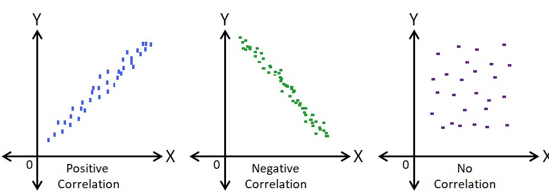

### 1.3.1. Pearson İlişki Katsayısı

İki nicel değişken arasında ilişkinin derecesini belirlemek için kullanılır.
$$r_{XY}=Cov(X,Y)/S_X S_Y$$

### 1.3.2. Spearman İlişki Katsayısı

İki sıralı (ordinal) değişken veya bir sıralı ve bir sürekli değişken arasındaki doğrusal ilişkiyi ifade eder. Değişkenler oransal ya da aralıklı ölçek ile elde edilmiş ancak normal dağılıma uygunluk göstermiyorsa da Spearman korelasyonu kullanılır.
$$r_s=(6∑d^i )/(n(n^2-1))$$

Spearman’in ρ katsayısı değerleri de (aynı Pearson’un çarpım-moment korelasyon katsayısı gibi) -1 ile +1 arasında değişir. Uç değerler (yani ρ=-1 ve ρ=+1 ve yakın değerler) iki değişken sıralaması arasında bağlantının çok iyi olduğunu (eğer sıralamalar noktalar olarak bir serpme diyagramına konulursa hepsinin çizilen bir doğru üzerinde olduğunu) gösterirler. Eğer ρ<0 ise, sıralamalar arasında ters yönlü değişim vardır; yani biri artınca diğeri azalır ve aksi olur. Eğer ρ>0 ise sıralamalar arasında birlikte (yani birlikte artma veya eksilme) değişme görülür. Eğer ρ=0 ise, sıralamalar arasında hiçbir bağlantını bulunmadığı (ve serpme diyagramı üzerinde noktaların rastgele dağıldıkları) sonucu çıkartılır.

## 1.5.Grafik Gösterimler

Veri kümelerinin özetlemesinde en kolay ve yaralı teknikleridir. • Değişkenler ile ilgili bilgi verici yapıdadır. • Verilerdeki ilişki ve bağıntılardan, verileri tanımlamak interpolasyon ve extra polasyon yapmak istenebilir.

### 1.5.1. Nokta Çizimleri

Veri sayısının az olduğu durumlar için fikir edinmek amaçı ile, özellikle elde yapılacak basit grafiklerdir. • Tek eksen üzerinde veri saçılımı gösterir. • Nicel veriler için geçerlidir. • Uç değerler ve gözlem etkinlikleri açısından bilgi vericidir. • Verilerdeki boşlukları (gap) gösterir. • Değişkenlerin karşılaştırılmasında yaralıdır. • Dağılım hakkında bilgi vermez. Histograma benzer. Verilerin daha sık aralıkta ve böylece daha dar bir alanda özetlendiği çizimlerdir.

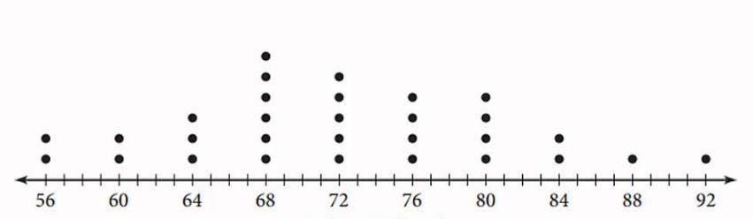

### 1.5.2. Kutu Grafiği

Verilerin çeyreklik değerlerine göre gösterimidir. Histogram ve nokta çizimleri farklı görünüme sahip olamakla birlikte veri ile ilgili yarıntılı bilgi verir. Konum, yayılım ve çarpıklık ile ilgili bilgi verir. Dağılımın kuyrukları ve bu kuyrukların yayılım ile ilgili bilgi verir. Uç değerleri görmek için olanaktır. Bu değerler aykırı değerde olabilir. Birden fazla veri kümesinin karşılaştırılmasına yararlıdır. Uç değerlere karşı dirençlidir. Grafiğin çizimi için ortanca, birinci ve üçüncü çeyrek değerleri hesaplanır ve

$$DAG (Çeyrekler Arası Uzaklık)=d=Q_3-Q_1$$

farkı bulunur. Q_3 ve Q_1farkı arasında yatay veya dikey eksende kutu çizilir. Kutunun içine ortanca çizgisi çizilir ve her iki ucundan, $A=Q_1-1.5d$ ve $B=Q_3+ 1.5d$ Uzunlukları kuşkulu gözlem sınırları olarak tanımlar. Bunlara eşik değerleri denir.Uç değerler eşik değerlerinin dışında olur ve işaretler.

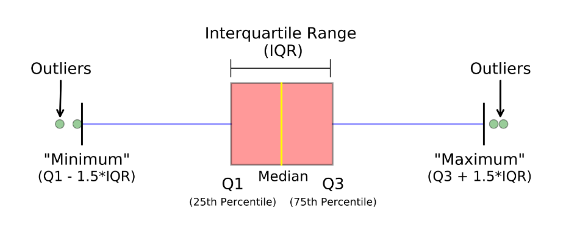

### 1.5.3 Histogram

Veri dağılımını özetlemenin en çok kullanılan yoludur. Veri genişliğini eşit uzunluktaki aralıklara bölerek gösterilir. • Büyük veri kümelerinde kullanılır. • Dağılım hakkında bilgi verir. • Genellikle verini yoğunlaştığı konumları gösterir. • Büyük veya küçük değerlere çarpık olması verilerde dönüşüm yapılabilceğini gösterir.

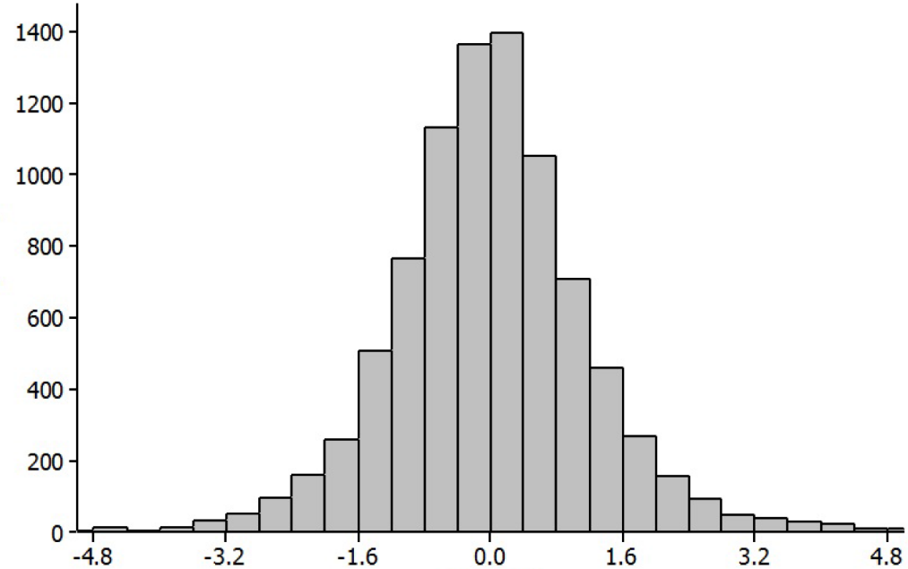

Çizimlerde alınacak sınıf sayısı için birçok eşitlik kullanılır. Büyük veri kümeleri için Sturges’in
$$k=⌈loga(2n)+1 ⌉ ~ ve~ h=Genişlik/k$$

### 1.5.4. Q-Q Plot

Veri kümesini belirli bir dağılıma uyumunun incelenmesidir. Genelde en çok veri kümesinin normal dağılımlı olup olmadığını anlamak için yapılır.Ayrıca iki ayrı veri kümesinin aynı dağılımlı olup olmadığını göstermek içinde kullanılır.

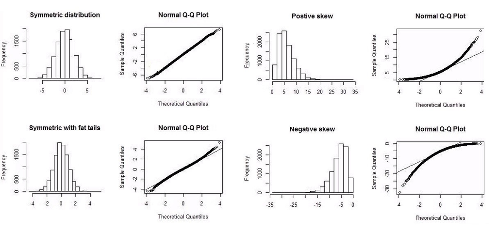

### 1.5.5. Saçılım Grafiği

İki ya da daha çok değişken arasındaki çizimler, aykırı değerlerin varlığı bakımından, değişkenlerin birliktelikleri yada bağımsızlıkları değişkenlerin etkinlikleri ve işlevsel yapı bakımından önemli bilgi verirler. İki değişken arasındaki ilişkinin yapısını ve yönünü verir.

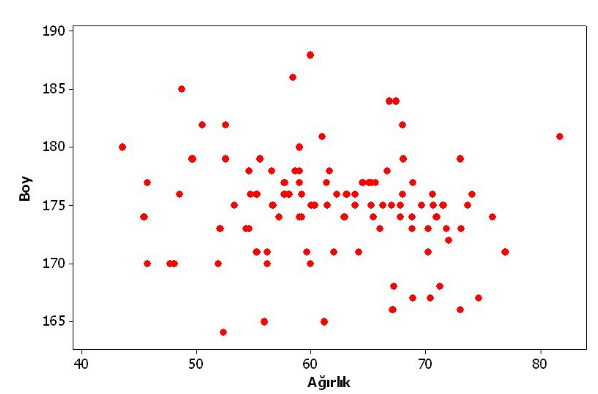

## 1.6. Verilerdeki Eksik Değerler

Veri kümesinde eksik değerlerin varlığı ön inceleme sırasında giderilmesi gereken bir sorundur. Bir gözlemin değişken değerlerinin tümünde eksik gözlem ise veriden çıkartılır. Bu değerlerden ötürü çok sayıda gözlemin çıkartılması bilgi kaybına neden olur. Eksik değerler rastgele dağılmamış ise gözlemlerin çıkartılması, örneklemin bozulmasına ve değişimin yeterince açıklanamamasına neden olur. Eksik değerler durumunda, sorunu gidermek için farklı çözüm yolları vardır.

### 1.6.1. Çözüm Yolları

Eksik değer durumunda , kümeden çıkartma yada değer atama yöntemleri kullanılır. **1- Gözlemlerin Çıkartılması** Az sayıda eksik değer için yaralıdır.Bu değişkenler rastgele dağılmamış ise veri kümesinden çıkartılması uygun değildir. **2-Ön Bilgi Kullanarak Kestirme** Özel bir konu için toplanmış verilerde ortaya çıkan eksik gözlemlerle ilgili yaklaşık kestirim yapılabilir. Bu kestirim önceki araştırmalardan yola çıkılarak yapılır. **3-Ortalama/Ortanca Kullanma** En kolay ve en basit yol her bir değişkenin eksik olmayan değerlerinin ortalamasını/ortancasını kullanmaktır. Bu ortalama/ortanca o değişkendeki eksik gözleme yazılır. **4-Regresyon Yöntemi** Kestirilecek eksik değerin bulunduğu değişken bağımlı (y) , diğer değişkenler bağımsız değişken olarak alınır. Bu değişkenlerden elde edilen denklemleden o gözlem için ön kestirim yapılır.

## 1.7. Veri Analizinde Dönüşümler

Ham veri üzerinde daha bilgi verici olması ve daha iyi özetleme yapmak için veriler üzerinde dönüşümler yapmak gerekir. Dönüşümler, • Veriyi basitleştirmek, yorumlamayı kolaylaştırmak, • Simetrikliği veya normalliği sağlamak, • Doğrusallık veya doğru fonksiyonel biçimi yakalamak, • Gözlemler arasındaki bağımlılığı kaldırmak için kullanılır.

### 1.7.1. Logaritmik Dönüşüm

Sağa veya sola çarpık değişim aralığının yüksek olduğu ve merkezindeki simetrinin önemli olduğu veri setlerinde varyans dengeleme dönüşümü yapılır.Veri setindeki tüm değerlerin logaritması alınır. Fakat yorum yaparken verileri eski haline dönüştürülmelidir.

# 2. NORMAL DAĞILIM

## 2.1. Standart Normal Dağılım

Normal dağılımı kullanarak bazı olasılık değerlerini elde etmek çok zor ve zahmetli bir iştir. Bu yüzden elde edilen normal dağılımın ortalaması 0 a ve varyansı da 1 e eşitlenerek daha kolay işlem yapılması sağlanabilir. Bu işlem için kullanılan yönteme ise standart normal dağılım denir.
$$Z= (x-μ)/σ$$

## 2.3. Merkezi Limit Teoremi

Bağımsız ve aynı dağılımı gösteren değişkenlerin toplamı ya da aritmetik ortalaması yaklaşık olarak normal dağılım halini alır. Fakat bu işlemin gerçekleşmesi için yeterli büyüklükte bir değişken uzayı büyüklüğüne sahip olmanız gerekmektedir. Olasılıkta çekim gücü gösteren bir dağılım vardır. Ve ortalamalar belirli bir limitten sonra dağılım olarak bu dağılıma yakınsar. Dağılım ne şekilde olursa olsun n sayısı artış gösterdikçe limitte ortalaması μ olan bir standart dağılıma yakınsama gösterir.
$$S_n= X_1+⋯+X_n=∑X_i$$

Rassal değişkenlerin toplamı olmak üzere,
$$Z_n=(S_n-nμ)/(σ√n)$$

## 2.4. Çarpıklık Ve Basıklık Ölçüleri

### 2.4.1.Çarpıklık$(α_3)$

Bir dağılıma ilişkin ölçme sonuçlarının nasıl dağıldığı hakkında bilgi verir.

- Momentlere Dayalı Çarpıklık Ölçüsü
  $$α_3=M_3/S^3 =((∑(x_i-x ̅)^3 )/n)/S^3$$

$α_3=0$ ise veri simteriktir

$α_3>0$ ise veri sağa çarpık

$α_3<0$ ise veri sola çarpık

### 2.4.2. Basıklık$(α_4)$

Basıklık bir sınıftaki değişim miktarının göstergesidir.

- Momentlere Dayalı Çarpıklık Ölçüsü

$$α_4=M_4/S^4 =((∑(x_i-x ̅)^4 )/n)/S^4$$

$α_4=3$ ise veri normaldir

$α_4>3$ ise verinormale göre sivridir

$α_4<3$ ise veri normale göre basıktır

## 2.5. Veri Setindeki Değişkenleri Normalliğinin İncelenmesi

Normallik varsayımının incelemesinin amacı verilmiş bir veri dizisinin normal dağılıma uygunluk iyiliğinin incelenmesidir. Test edilmesinde grafiksel yöntemler ve hipotez testleri en çok kullanılan yöntemlerdir.

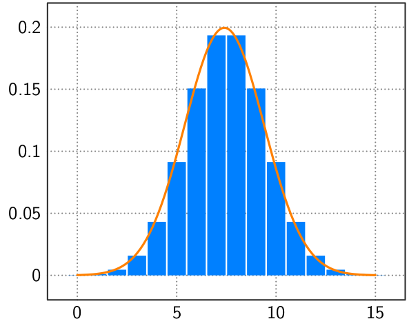

# 3.VARYANS ANALİZİ (ANOVA)

Varyans analizi (ANOVA), k gruptan (k>2) elde edilen veri setinde incelenen değişkene ait olan genel varyansı (genel değişimin), bu değişime katkıda bulunan öğelerine ayırarak analiz etmeyi sağlayan bir yöntemdir. Varyans analizi veri yapısına bağlı olarak çok değişik işlevler yerine getiren bir yöntemdir. Veri yapısına ve çalışma dizaynına göre değişik modeller içerir.

## 3.1.Tek Yönlü Varyans Analizi(One-Way Anova)

Bağımsız k>2 gruplu bir çalışma grubunda, incelenen bir değişkene ait elde edilen verilerin analizinde yararlanılan bir yöntemdir. K bağımsız örneklem varyans analizi olarak tanımlanabilmektedir. Bağımsız örneklerde t testinin ikiden fazla grup için genellenmiş bir şeklidir. *Tek yönlü varyans analizine ait varsayımlar;*

- İncelenen değişken (Y) her bir ana kütlede normal dağılım göstermelidir.
- Ana kütle etkileri toplanabilir olmalı ve etkilerin toplamı sıfır olmalıdır.
- Grup ortalamaları ve standart sapmaları arasında bir doğrusallık olmamalıdır.

Birbirinden bağımsız $𝜇_1, 𝜇_2, … , 𝜇_𝑘$ ortalamalı ve $𝜎^2$ varyanslı normal dağılım gösteren k tane ana kütleden ni hacimli (i=1,2,…,k) rastgele örnek alınarak elde edilen veri setini analiz etmek için tek yönlü varyans analizi kullanılır. Tek yönlü varyans analizinde test edilen hipotezler aşağıdaki gibidir. $ 𝐻0: 𝜇1 = 𝜇2 = ⋯ = 𝜇𝑘$

Burada ana kütlelerden alınan örnekler birbirlerinden bağımsızdır ve örnek birim sayılarının benzer olması gerekmez. Tek yönlü varyans analizi incelenen değişken genel olarak 𝑌𝑖𝑗 olarak gösterilir. Burada; i=1,2,…,k ve j=1,2,…, ni olmak üzere k: grup sayısını j: birim sayısını ni : i. grupa ait örnek büyüklüğünü göstermektedir. Buradan yola çıkarak incelenen değişkene ait genel ortalama,

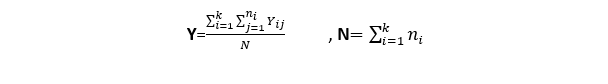

**Bu durumda genel kareler toplamı,**

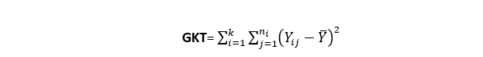

Genel kareler toplamı gruplar arası kareler toplamı ve grup içi kareler toplamı olarak parçalanabilir. **GKT=GAKT+GİKT** Grup içi kareler toplamına hata kareler toplamında denilmektedir. **Gruplar arası kareler toplamı,**

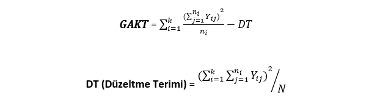

**Grup içi kareler toplamı,**

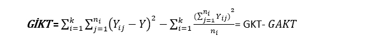

Genel serbestlik derecesi (gsd)=N-1 Gruplar arası serbetlik derecesi(gasd)=k-1 Grup içi serbestlik derecesi (hsd)=N-k
$$N-1=(k-1)+(N-k)$$

Kareler toplamları ve bir kare toplamına ait serbestlik dereceleri kullanılarak varyans tahminleri olan kareler ortalamaları hesaplanır. Gruplar arası kareler ortalaması=GAKT/gasd Grup içi kareler ortalaması=GİKT/hsd Grup içi kareler ortalaması aynı zamanda hata kareler ortalaması olarak bilinir ve anakütle varyansının tahmincisidir. tek yönlü varyans analizi aruplar arasınsaki değişimin önemliliğini test etmek için F test istatistiği kullanılır.
$$𝐹 = 𝐺𝐴𝐾𝑂/𝐻𝐾𝑂$$

F test istatistiği iki serbestlik derecesine sahip F dağılımı gösterir. Bu dağılımın birinci serbestlik derecesi pay serbestlik derecedir sd1=gasd’dir. İkinci serbestlik derecesi payda serbestlik derecesidir ve sd2=hsd’dir. Bu durumda hesaplanan F test istatistiği F dağılımından elde edilen F kritik değerine göre karşılaştırılır ve $F_{test}<F_{0.05,sd_1,sd_2}$ ise p>0.05 olarak hesaplanır. Budurumda $H_0$ hipotezi rededilmez. $F_{test}>F_{0.05,sd_1,sd_2}$ ise p<0.05 olarak hesaplanır. Bu durumda da $H_0$ hipotezi rededilir. Tek yönlü varyans analizi sonuçları aşağıdaki gibi özet bir tablo halinde sunulur.

| Değişim aynağı | Serbestlik Derecesi | Kareler Toplamı | Kareler Ortalaması | F İstatistiği |
| --- | --- | --- | --- | --- |
| Gruplar Arası | k-1 | GAKT | GAKO | GAKO/GİKO |
| Grupu İçi(Hata) | N-k | GİKT | GİKO |  |
| Toplam(Genel) | N-1 | GKT | - |  |

### 3.1.1. Kruskal-Wallis H Testi

Kruskal-Wallis H testi (KWH) parametrik olmayan tek yönlü varyans analizi yöntemidir. K bağımsız örneğin benzer ortanca değerli ana kütlelerin rastgele örnekleri olup olmadığını test eder. KWH testi uygulanacak verilerin aralıklı ya da oransal ölçekli olması gerekir.

**KWH testinde aşağıdaki hipotezler test edilir.**

$H_0$: k örnek benzer medyanlı ana kütlelerden alınmış örneklerdir.

$H_A$: k örnekten an az birinin medyanı diğerlerinden farklıdır.

KWH testinde gözlem değerleri yerine bu değerlere ait sıralama puanları kullanılır. Her grubun sıralama puanları toplamı ele alınarak H test istatistiği aşağıdaki gibi hesaplanır.

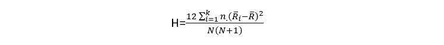

# 4. REGRESYON ANALİZİ

## 4.1. Çoklu Doğrusal Regresyon

k sayıda değişkenin ilişkileri ölçmek için kullanılır. Hem tanımlayıcı hem de çıkarımsal istatistik sağlar. Basit doğrusal regresyon bize normal dağılmış, hakkında aralıklı/oranlı ölçekle veri toplanmış iki değişken arasında doğrusal ilişki olup olmadığını test etme olanağı verir. Değişkenlerden biri tahmin, biri sonuç değişkenidir. k sayıda bağımsız değişkenin olduğu doğrusal regresyon modeli aşağıdaki gibi yazılır.
$$y= β_0+β_1 X_1+β_2 X_2+⋯+β_k X_k+ε$$
(4.1)

### 4.1.1. En Küçük Kareler Kestirimi

$β_0, β_1, β_2,..., β_k$ parametreleri bilinmeyenlerdir ve örneklem verileri üzerinden kestirimler gerekir. $(y_1,x_11,x_12,…,x_1k ),…,(y_n,x_n1,x_n2,…,x_nk )$ olmak üzere n sayıda ve k bağımsız değişkenden oluşan veri kümesi olduğu varsayılır.

#### 4.1.1.1. Regresyon Katsayılarının En Küçük Kareler Kestirimi

$y_i, β_1, β_2,..., β_k$ gözlemleri ile regresyon doğrusu arasındaki farkların en küçük olacak şekilde kestirilir. Denklem (4.1)’deki regresyon katsayılarının kestirimi için kullanılır. n>k gözlemin olduğunu varsayılarak aşağıdaki denklem yazılır.

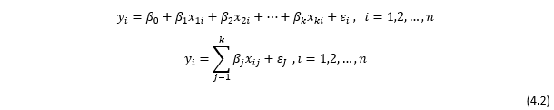

En küçük kareler fonksiyonu aşağıdaki gibidir:

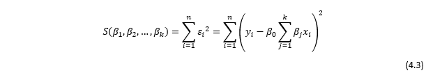

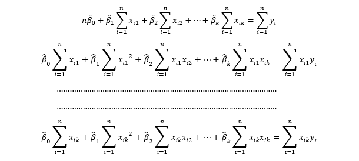

Denklemini verir. Bu denklemler en küçük kareler normal denklemleri olarak adlandırılır. Normal denklemlerinin çözümü β_0 , β_1 〖,β〗_2,…, β_k en küçük kareler kestiricilerini verecektir. Çoklu regresyon modelleriyle ilgilenirken onları matris içinde ifade daha uygundur. Verilerin ve sonuçların daha kısa ve öz bir biçimde sağlar Denklem(4.2)’da verilen modelin matris gösterimi,
$$y=Xβ+ε$$

biçimindedir. Buradak, matrisler aşağıdaki gibidir;

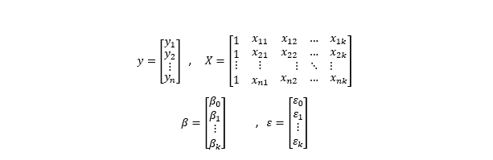

y:Gözlemler vektörü X:Bağımsız değişkenler matrisi β:Regeresyon Katsayıları vektörü ε:Rastgele hatalar vektörü Aşağıda verilen S(β) fonsiyonunu minimize ederek $\hat{\beta}$ en küçük kareler kestiricileri vektörünü elde ederiz:

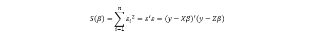

S(β) aşağıdaki gibi elde edilir:

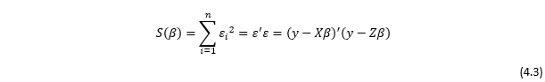

Denklem (4.3)’indeki β’ya göre türevi alınıp basitlştirilirse:

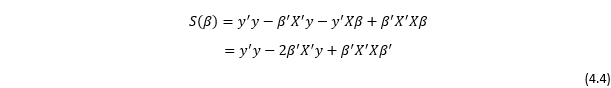

Denklem(4.4)’ün matris gösterimi aşağıdaki gibidir

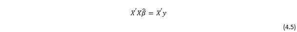

Denklem (4.5)’ün matris gösterimi aşağıdaki gibidir

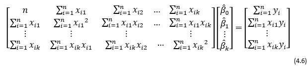

Denklemi (4.6) çözmek için her iki tarafı (X’X)-1 ile çarpılır. β’nın en küçük kareler kestiricisi bulunur.

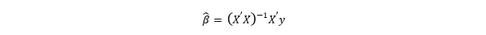